# Lab 00 - Hello IDS!

Liam Kamphuis

2025-11-02

### Load packages and data

```r
library(tidyverse)
```

### Exercises 16-17

We set up the data frame. Edit the data below to include information about your team members.

```r
team_data <- tibble(
  name = c("Liam", "Cole", "Logan",
           "JP", "Alec"),
  github_username = c("LiamKamphuis", "clooney", "logan-arm",
                      "john-paul", "a-n-a"),
  colour = c("purple1", "darkgoldenrod3", "black",
             "cadetblue3", "green3"),
  hobby = c("Ice Hockey", "Tennis", "Film",
            "Physics", "Football"),
  favourite_number = c(4, 6, 3, 8, 7)
  )

team_data
```

```
## # A tibble: 5 × 5
##   name  github_username colour         hobby      favourite_number
##   <chr> <chr>           <chr>          <chr>                 <dbl>
## 1 Liam  LiamKamphuis    purple1        Ice Hockey                4
## 2 Cole  clooney         darkgoldenrod3 Tennis                    6
## 3 Logan logan-arm       black          Film                      3
## 4 JP    john-paul       cadetblue3     Physics                   8
## 5 Alec  a-n-a           green3         Football                  7
```

### Exercise 18

We now work on visualising our data.

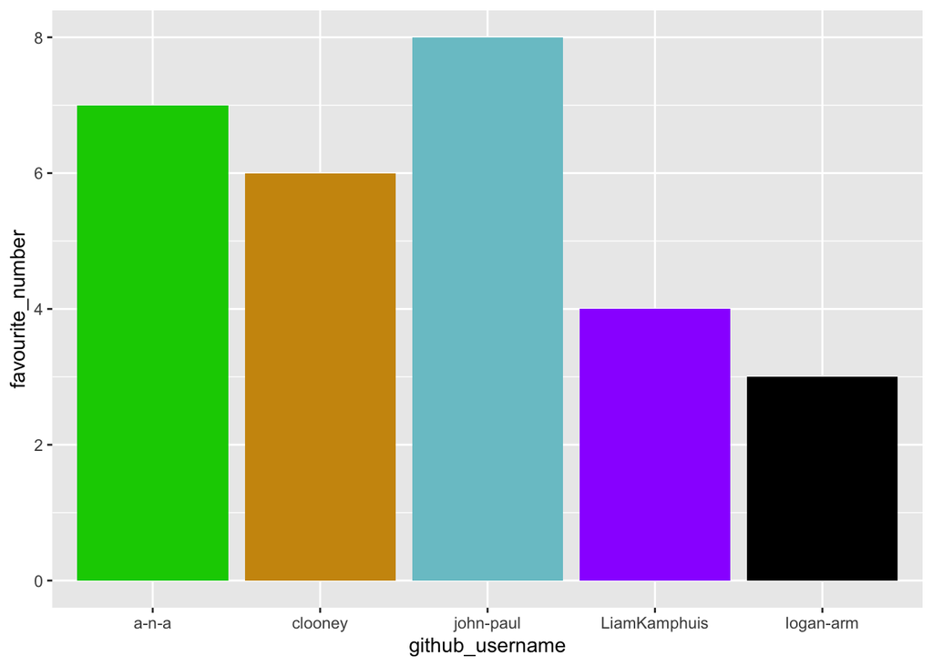

```r
p1 <- ggplot(data = team_data,
             mapping = aes(x = github_username,
                           y = favourite_number,
                           fill = colour),
             ) +
   geom_col() +
   scale_fill_identity()
p1
```

### Exercises 19

Change the text of the plot title and axis labels.

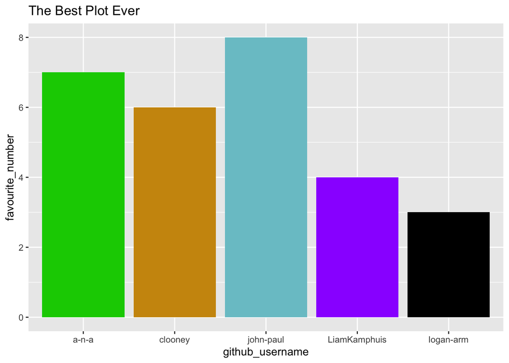

```r
p1 + labs(x = "github_username",
          y = "favourite_number",
          title = "The Best Plot Ever")
```

### Exercise 20

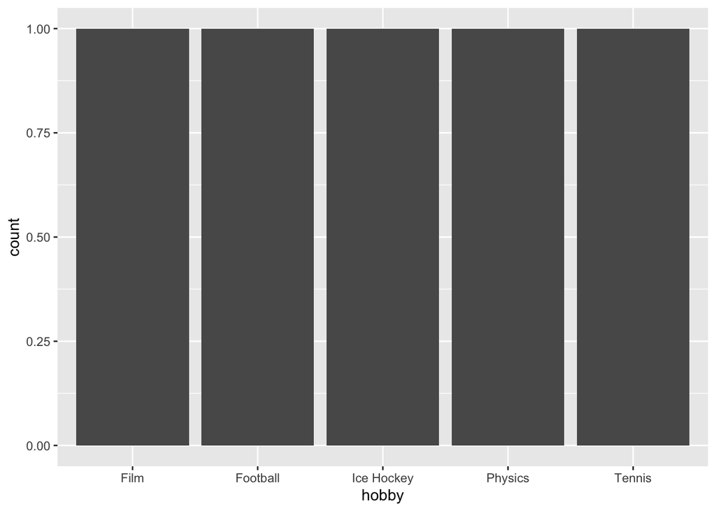

```r
p2 <- ggplot(team_data, aes(x = hobby)) +
  geom_bar()
p2
```

Any type of variable with a high number of possible values that can be observed of it and it is unlikely to observe the same result multiple times will be awful to visualize with a histogram for observed frequency. This is very evident with continuous variables in which it is nearly impossible to observe a single value multiple times. Therefore, it is useful to view either probability density or create buckets of values. In this example, it would be useful to bucket similar answers to hobbies in more generalized histogram bars, such as hobbies correlating to “sports” or “arts”